# Reproducible Research Peer Assessment 2: US Storm Damage Effects on Health and Economic Damages

Matthew Fergusson

July 24, 2015

## Synopsis

This analysis aims to answer 2 key questions about the U.S. National Oceanic and Atmospheric Administration’s (NOAA) storm database:

1. Across the United States, which types of events (as indicated in the EVTYPE variable) are most harmful with respect to population health?
2. Across the United States, which types of events have the greatest economic consequences?

The analysis will look at the total number of fatalities and injuries and damages due to these events in the US from 1985 onward. To determine what is most harmful the report looks at events with the top 10 most fatalities and injuries combined during that time period. To determine the greatest economic impact the report looks at events with the top 10 highest combined property and crop damages during that time period.

## Background

This report looks at the data available in the U.S. National Oceanic and Atmospheric Administration’s (NOAA) storm database. This database records information about major storms and other weather events in the United States. The records record when and where these events take place and estimates of injuries, property damage, and fatalities.

## Data Processing

First the libraries that would be used were set and then the raw data file was downloaded from the Coursera website and read in as a CSV. The code for these steps are shown below:

```r
##Data Processing
###########################################
# Set Libraries
###########################################
library(tidyr)
library(ggplot2)
library(dplyr)
library(sqldf)
library(lubridate)

###########################################
# Download data
###########################################

#file URL
fileUrl <- "https://d396qusza40orc.cloudfront.net/repdata%2Fdata%2FStormData.csv.bz2"
#Destination file path and file name
fileDest <- "C:/Users/mfergusson/Desktop/MTF Personal/Education - Coursera Data Science Specialization/05 - Reproducible Research/Peer Assessment 2/repdata-data-StormData.csv.bz2"

#directory for R scripts and other work
Base_wd = "C:/Users/mfergusson/Desktop/MTF Personal/Education - Coursera Data Science Specialization/05 - Reproducible Research/Peer Assessment 2"
setwd(Base_wd)

#download file
  #download.file(fileUrl, destfile = fileDest)
#unzip all to location

StormData <- read.csv("repdata-data-StormData.csv.bz2", header=TRUE, sep = "," , quote = "\"")
```

After looking at the data in the viewer window the “BGN_DATE”“,”EVTYPE“,”FATALITIES“,”INJURIES“,”PROPDMG“,”PROPDMGEXP" , “CROPDMG”, and “CROPDMGEXP” fields were the only fields carried forward in the analysis because they seemed most appropriate for answering the questions posed about health and economic damages.

```r
names(StormData)
```

```
##  [1] "STATE__"    "BGN_DATE"   "BGN_TIME"   "TIME_ZONE"  "COUNTY"
##  [6] "COUNTYNAME" "STATE"      "EVTYPE"     "BGN_RANGE"  "BGN_AZI"
## [11] "BGN_LOCATI" "END_DATE"   "END_TIME"   "COUNTY_END" "COUNTYENDN"
## [16] "END_RANGE"  "END_AZI"    "END_LOCATI" "LENGTH"     "WIDTH"
## [21] "F"          "MAG"        "FATALITIES" "INJURIES"   "PROPDMG"
## [26] "PROPDMGEXP" "CROPDMG"    "CROPDMGEXP" "WFO"        "STATEOFFIC"
## [31] "ZONENAMES"  "LATITUDE"   "LONGITUDE"  "LATITUDE_E" "LONGITUDE_"
## [36] "REMARKS"    "REFNUM"
```

```r
#Keep:
# "BGN_DATE"" / "EVTYPE" / "FATALITIES" / "INJURIES" / "PROPDMG" / "PROPDMGEXP" /  "CROPDMG" / "CROPDMGEXP"

StormData_2 <- select(StormData, BGN_DATE,  EVTYPE, FATALITIES, INJURIES, PROPDMG, PROPDMGEXP, CROPDMG, CROPDMGEXP )
  StormData_2$FATALITIES <- as.numeric(StormData_2$FATALITIES)
  StormData_2$INJURIES <- as.numeric(StormData_2$INJURIES)
  StormData_2$PROPDMG <- as.numeric(StormData_2$PROPDMG)
  StormData_2$CROPDMG <- as.numeric(StormData_2$CROPDMG)
  StormData_2$BGN_DATE <- as.POSIXct(StormData_2$BGN_DATE, format = "%m/%d/%Y %H:%M:%S")
  StormData_2$year <- year(StormData_2$BGN_DATE)
```

After this the data needed to be examined to look for any outliers. The distribution of events was looked at first. It appeared that the records for events doesn’t approach modern levels until around 1990. Despite this I have decided to look at all events from 1985 onward to capture the events that have occurred in my lifetime.

Limiting the data like this will underestimate the impact of less frequent events such as earthquakes; however, it is a balance between looking at less events recorded in the past which would have more heavily weighted those major events and looking at evenly weighted data that might exclude those based on their probability of occurrence. I have chosen to stick with the time periods with more comprehensive data coverage.

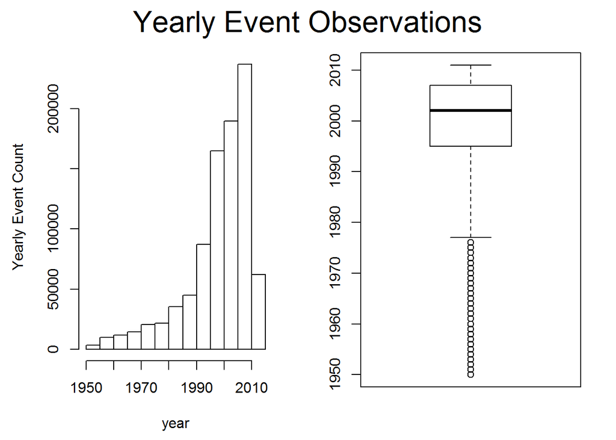

```r
#look at data distribution by year
  par(mfcol = c(1,2))
  par(mar = c(4.5,4.5,3,2))
  hist(StormData_2$year
       , main=""
       , xlab="year"
       , ylab="Yearly Event Count")
  par(mar = c(3,3,3,2))
  boxplot(StormData_2$year)
  mtext("Yearly Event Observations", side = 3, line = -2, outer = TRUE, cex = 2)
```

```r
#Filder out loans before 1985
    #looks like modern reading start to come into play around 1990 but I would like to
    #look at all the data points within my lifetime to make things interesting for me
  StormData_2 <- filter(StormData_2, StormData_2$year >= 1985)
```

Other aspects of the data that needed to be examined were the “PROPDMGEXP” and “CROPDMGEXP” fields. the values in these fields appear to indicate that they should be used as an exponential value to calculate the actual damages values (ex. PROPDMG = $213.00 and PROPDMGEXP = 3: therefore the actual property damage is 213*10^3 = $213,000.00). In these fields there were number values and letter values. Because this data was collected and populated over time from different sources I assume there were different data conventions and I have interpreted the letter values as follows

- “B” or “b” - Billions (10^9) therefore PROPDMGEXP/CROPDMGEXP = 9
- “M” or “m” - Millions (10^6) therefore PROPDMGEXP/CROPDMGEXP = 6
- “K” or “k” - Thousands (10^3) therefore PROPDMGEXP/CROPDMGEXP = 3
- “H” or “h” - Hundreds (10^2) therefore PROPDMGEXP/CROPDMGEXP = 2
- “?”, “+”, “-”, or “” - Undefined values that will be given a default of PROPDMGEXP/CROPDMGEXP = 0

The code for these modifications to the “PROPDMGEXP” and “CROPDMGEXP” fields and creation of modified damages fields are shown below:

```r
#examing the "EXP" fields
  unique(StormData_2$PROPDMGEXP)
```

```
##  [1] K   M B m + 0 5 6 ? 4 2 3 h 7 H - 1 8
## Levels:  - ? + 0 1 2 3 4 5 6 7 8 B h H K m M
```

```r
  unique(StormData_2$CROPDMGEXP)
```

```
## [1]   M K m B ? 0 k 2
## Levels:  ? 0 2 B k K m M
```

```r
#create modified "PROPDMGEXP" and "CROPDMGEXP" fields to treat them as exponential values of the damages
  StormData_3 <- sqldf(" SELECT *
        ,  case when PROPDMGEXP in ('B','b') then 9
                when PROPDMGEXP in ('M','m') then 6
                when PROPDMGEXP in ('K','k') then 3
                when PROPDMGEXP in ('H','h') then 2
                when PROPDMGEXP in ('?','-','', '+') then 0
                else PROPDMGEXP
           end as PROPDMGEXP_mod
        ,  case when CROPDMGEXP in ('B','b') then 9
                when CROPDMGEXP in ('M','m') then 6
                when CROPDMGEXP in ('K','k') then 3
                when CROPDMGEXP in ('H','h') then 2
                when CROPDMGEXP in ('?','-','', '+') then 0
                else CROPDMGEXP
           end as CROPDMGEXP_mod
        FROM StormData_2")
#create modified damages fields to make values comparable for top 10
  StormData_3$PROPDMG_mod <- StormData_3$PROPDMG * 10^StormData_3$PROPDMGEXP_mod
  StormData_3$CROPDMG_mod <- StormData_3$CROPDMG * 10^StormData_3$CROPDMGEXP_mod
```

Following these modifications to the data set, the data was prepped to create results that would show the top 10 events that cause the most health related damage (fatalities and injuries) and the top 10 events that cause the most economic damages.

```r
#Take sum of all injuries, fatalities and economic damages by event type
  #using modified fields for damages
StormData_4 <- sqldf("SELECT EVTYPE
      ,sum(FATALITIES) as FATALITIES_TOT
      ,sum(INJURIES) as INJURIES_TOT
      ,sum(FATALITIES) + sum(INJURIES) as FAT_INJ_TOT
      ,sum(PROPDMG_mod) as PROPDMG_TOT
      ,sum(CROPDMG_mod) as CROPDMG_TOT
      ,sum(PROPDMG_mod) + sum(CROPDMG_mod) as ECONDMG_TOT
      ,count(*) as OCCURENCES
      FROM StormData_3
      GROUP BY EVTYPE")

#Isolate Health related data
      StormData_Health <- select(StormData_4, EVTYPE, FATALITIES_TOT, INJURIES_TOT, FAT_INJ_TOT)
    #Top 10 Inuries and Fatalities Combined
      StormData_Health <- arrange(StormData_Health, desc(FAT_INJ_TOT))
      StormData_Health_Top10_Both <- StormData_Health[1:10,]
    #Top 10 fatalities
      StormData_Health <- arrange(StormData_Health, desc(FATALITIES_TOT))
      StormData_Health_Top10_Fat <- StormData_Health[1:10,]
    #Top 10 Injuries
        StormData_Health <- arrange(StormData_Health, desc(INJURIES_TOT))
        StormData_Health_Top10_Inj <- StormData_Health[1:10,]

    #Combine for table display
     Health_Impact_comp <- cbind(as.character(StormData_Health_Top10_Both$EVTYPE), as.numeric(StormData_Health_Top10_Both$FAT_INJ_TOT)
            , as.character(StormData_Health_Top10_Fat$EVTYPE), as.numeric(StormData_Health_Top10_Fat$FATALITIES_TOT)
            , as.character(StormData_Health_Top10_Inj$EVTYPE), as.numeric(StormData_Health_Top10_Inj$INJURIES_TOT))
     colnames(Health_Impact_comp) <- c("Top 10 Combined","Fatalities and Injuries","Top 10 Fatalities","Fatalities", "Top 10 Injuries","Injuries"  )

#Isolate Econ damage related data
    StormData_EconDMG <- select(StormData_4, EVTYPE, PROPDMG_TOT, CROPDMG_TOT, ECONDMG_TOT)
    #Top 10 Inuries and Fatalities Combined
    StormData_EconDMG <- arrange(StormData_EconDMG, desc(ECONDMG_TOT))
    StormData_EconDMG_Top10_Both <- StormData_EconDMG[1:10,]
    #Top 10 fatalities
    StormData_EconDMG <- arrange(StormData_EconDMG, desc(PROPDMG_TOT))
    StormData_EconDMG_Top10_PROP <- StormData_EconDMG[1:10,]
    #Top 10 Injuries
    StormData_EconDMG <- arrange(StormData_EconDMG, desc(CROPDMG_TOT))
    StormData_EconDMG_Top10_CROP <- StormData_EconDMG[1:10,]

    #Combine for table display
    EconDMG_Impact_comp <- cbind(as.character(StormData_EconDMG_Top10_Both$EVTYPE), as.numeric(StormData_EconDMG_Top10_Both$ECONDMG_TOT)
                                , as.character(StormData_EconDMG_Top10_PROP$EVTYPE), as.numeric(StormData_EconDMG_Top10_PROP$PROPDMG_TOT)
                                , as.character(StormData_EconDMG_Top10_CROP$EVTYPE), as.numeric(StormData_EconDMG_Top10_CROP$CROPDMG_TOT))
    colnames(EconDMG_Impact_comp) <- c("Top 10 Combined","Property and Crop Damage","Top 10 Property Damage","Property Damage", "Top 10 Crop Damage","Crop Damage")
```

## Results

The results for top health hazard events are shown below:

Comparison of combined ranking, fatality ranking, and injury ranking:

```r
Health_Impact_comp <- data.frame(Health_Impact_comp)

#display top 10 counts by impacts
 select (Health_Impact_comp, Top.10.Combined, Fatalities.and.Injuries)
```

```
##      Top.10.Combined Fatalities.and.Injuries
## 1            TORNADO                   33487
## 2     EXCESSIVE HEAT                    8428
## 3              FLOOD                    7259
## 4          TSTM WIND                    7077
## 5          LIGHTNING                    6046
## 6               HEAT                    3037
## 7        FLASH FLOOD                    2755
## 8          ICE STORM                    2064
## 9  THUNDERSTORM WIND                    1621
## 10      WINTER STORM                    1527
```

```r
 select (Health_Impact_comp, Top.10.Fatalities, Fatalities)
```

```
##    Top.10.Fatalities Fatalities
## 1            TORNADO       2002
## 2     EXCESSIVE HEAT       1903
## 3        FLASH FLOOD        978
## 4               HEAT        937
## 5          LIGHTNING        816
## 6              FLOOD        470
## 7          TSTM WIND        463
## 8        RIP CURRENT        368
## 9          HIGH WIND        248
## 10         AVALANCHE        224
```

```r
 select (Health_Impact_comp, Top.10.Injuries, Injuries)
```

```
##      Top.10.Injuries Injuries
## 1            TORNADO    31485
## 2              FLOOD     6789
## 3          TSTM WIND     6614
## 4     EXCESSIVE HEAT     6525
## 5          LIGHTNING     5230
## 6               HEAT     2100
## 7          ICE STORM     1975
## 8        FLASH FLOOD     1777
## 9  THUNDERSTORM WIND     1488
## 10      WINTER STORM     1321
```

Graph displaying top 10 events for fatalities and inruries combined

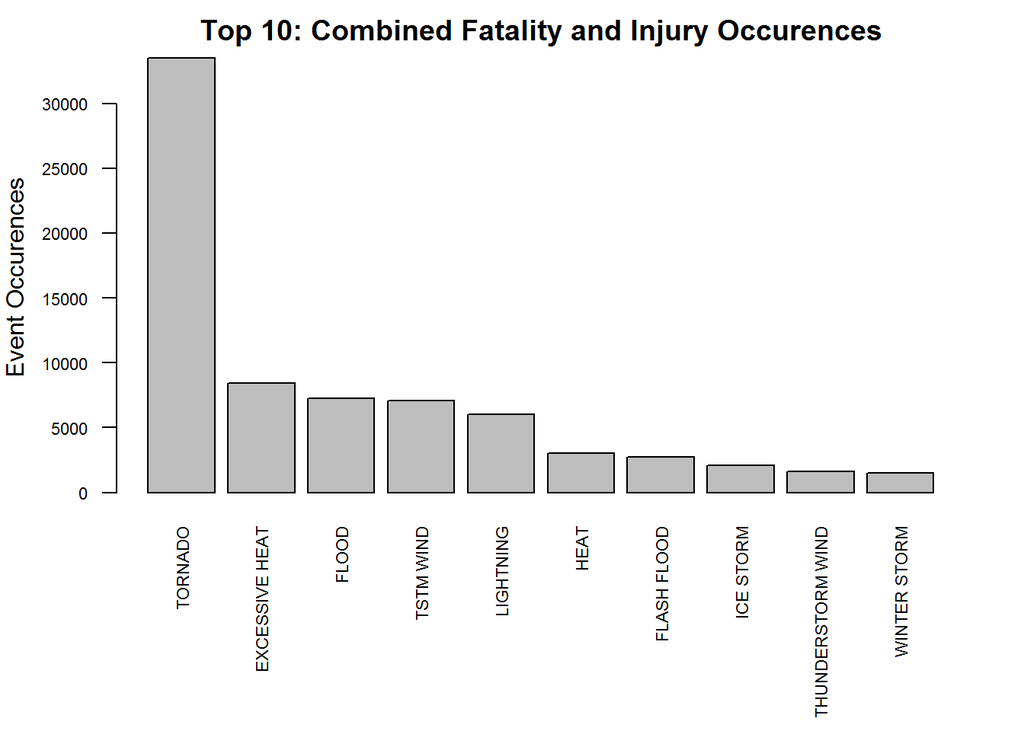

```r
par(mfcol = c(1,1))
par(mar =c( 8, 4, 2, 2))
barplot(StormData_Health_Top10_Both$FAT_INJ_TOT
        , las=2
        , names = StormData_Health_Top10_Both$EVTYPE
        , cex.names = 0.7
        , cex.axis = 0.7
        , xlab = ""
        , ylab = "Event Occurences"
        , main = "Top 10: Combined Fatality and Injury Occurences")
```

The results for most economically damaging events are shown below:

```r
EconDMG_Impact_comp <- data.frame(EconDMG_Impact_comp)

#display top 10 counts by impacts
select(EconDMG_Impact_comp, Top.10.Combined,Property.and.Crop.Damage)
```

```
##      Top.10.Combined Property.and.Crop.Damage
## 1              FLOOD             150319678257
## 2  HURRICANE/TYPHOON              71913712800
## 3        STORM SURGE              43323541000
## 4            TORNADO            36818801976.5
## 5               HAIL            18761221985.7
## 6        FLASH FLOOD            18243991078.5
## 7            DROUGHT              15018672000
## 8          HURRICANE              14610229010
## 9        RIVER FLOOD              10148404500
## 10         ICE STORM               8967041360
```

```r
select(EconDMG_Impact_comp, Top.10.Property.Damage,Property.Damage)
```

```
##    Top.10.Property.Damage Property.Damage
## 1                   FLOOD    144657709807
## 2       HURRICANE/TYPHOON     69305840000
## 3             STORM SURGE     43323536000
## 4                 TORNADO   36403848706.5
## 5             FLASH FLOOD   16822673978.5
## 6                    HAIL   15735267512.7
## 7               HURRICANE     11868319010
## 8          TROPICAL STORM      7703890550
## 9            WINTER STORM      6688497251
## 10              HIGH WIND      5270046295
```

```r
select(EconDMG_Impact_comp, Top.10.Crop.Damage,Crop.Damage)
```

```
##    Top.10.Crop.Damage Crop.Damage
## 1             DROUGHT 13972566000
## 2               FLOOD  5661968450
## 3         RIVER FLOOD  5029459000
## 4           ICE STORM  5022113500
## 5                HAIL  3025954473
## 6           HURRICANE  2741910000
## 7   HURRICANE/TYPHOON  2607872800
## 8         FLASH FLOOD  1421317100
## 9        EXTREME COLD  1292973000
## 10       FROST/FREEZE  1094086000
```

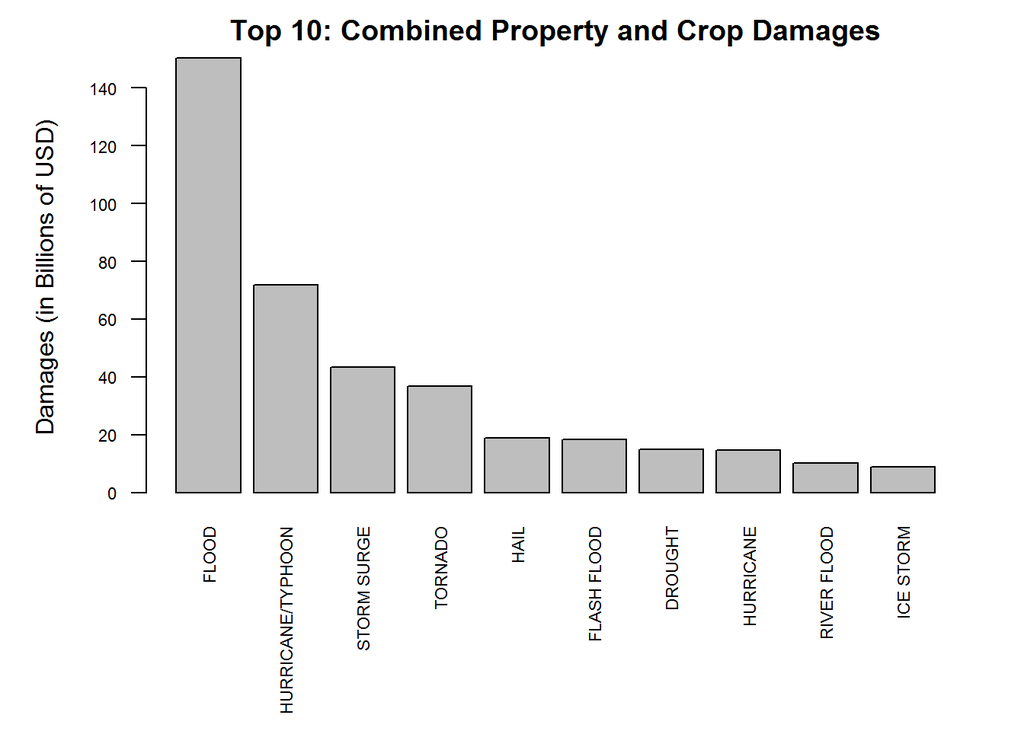

```r
#Change damage values to billions ($)
StormData_EconDMG_Top10_Both_Graph <- StormData_EconDMG_Top10_Both
StormData_EconDMG_Top10_Both_Graph$ECONDMG_TOT <- StormData_EconDMG_Top10_Both_Graph$ECONDMG_TOT / 10^9

par(mfcol = c(1,1))
par(mar =c( 8, 5, 2, 2))
barplot(StormData_EconDMG_Top10_Both_Graph$ECONDMG_TOT
        , las=2
        , names = StormData_EconDMG_Top10_Both_Graph$EVTYPE
        , cex.names = 0.7
        , cex.axis = 0.7
        , xlab = ""
        , ylab = "Damages (in Billions of USD)"
        , main = "Top 10: Combined Property and Crop Damages")
```